# Predicting student performances with attributes

Evangeline Tan

### Introduction

The data consisting of student’s achievement in two Portuguese secondary schools includes grades, demographic, social and school related features.

Collected using school reports and questionnaires, it includes two subjects: Mathematics (mat) and Portuguese language (por) which were modeled under binary/five-level classification and regression tasks.

Note: target attribute G3 has a strong correlation with attributes G2 and G1.  
This occurs because G3 is the final year grade, while G1 and G2 corresponds to 1st and 2nd period grades. It is more difficult to predict G3 without G2 and G1, but such prediction is much more useful.

Data: [Student](https://archive.ics.uci.edu/ml/datasets/student+performance)

Relevant papers: [Data Mining Prediction](http://www3.dsi.uminho.pt/pcortez/student.pdf)

Attributes: [GitHub](https://github.com/evantyy/predict-student-perf/blob/main/dataset/student-attributes.txt)

### Import data and libraries

```r
setwd("D:/et4_e")

# Import and prepare the student performance dataset
school1 = read.table("student-mat.csv",sep=";",header=TRUE)
school2 = read.table("student-por.csv",sep=";",header=TRUE)
schools = merge(school1,school2,by=c("school","sex","age","address","famsize","Pstatus","Medu","Fedu","Mjob","Fjob","reason","nursery","internet"))


# Changing characters to factors
school1[sapply(school1, is.character)] <- lapply(school1[sapply(school1, is.character)],
                                                 as.factor)
school2[sapply(school2, is.character)] <- lapply(school2[sapply(school2, is.character)],
                                                 as.factor)
schools[sapply(schools, is.character)] <- lapply(schools[sapply(schools, is.character)],
                                                 as.factor)
```

```r
# Check for missing values
sum(is.na(school1))
```

```
## [1] 0
```

```r
sum(is.na(school2))
```

```
## [1] 0
```

```r
sum(is.na(schools))
```

```
## [1] 0
```

### Details of data

```r
# Brief details of data given
library(dplyr)
library(tidyr)
library(ggplot2)

table(school1$school)
```

```
##
##  GP  MS
## 349  46
```

```r
table(school2$school)
```

```
##
##  GP  MS
## 423 226
```

```r
table(schools$school)
```

```
##
##  GP  MS
## 342  40
```

```r
table1 <- rbind(c(mean(school1$G1), mean(school1$G2), mean(school1$G3)),c(mean(schools$G1.x), mean(schools$G2.x), mean(schools$G3.x)))
colnames(table1) <- c("G1","G2","G3")
rownames(table1) <- c("Math","Math&Port")
table1
```

```
##                 G1       G2       G3
## Math      10.90886 10.71392 10.41519
## Math&Port 10.86126 10.71204 10.38743
```

```r
## Mean Grade of students in math did not improve throughout period.
```

Looking into the mean grades scored, we can observe that all math students and those who take both courses experienced a slight decrease in the mean grade as the school term goes on.

```r
table2 <- rbind(c(mean(school2$G1), mean(school2$G2), mean(school2$G3)),c(mean(schools$G1.y), mean(schools$G2.y), mean(schools$G3.y)))
colnames(table2) <- c("G1","G2","G3")
rownames(table2) <- c("Port","Port&Math")
table2
```

```
##                 G1       G2       G3
## Port      11.39908 11.57011 11.90601
## Port&Math 12.11257 12.23822 12.51571
```

```r
## Mean Grade of students in Portuguese have improved throughout period.
```

All Portuguese students and those who take both courses experienced a slight increase in mean grade as the school term goes on.

### Finding relationship between variables and Final Grade

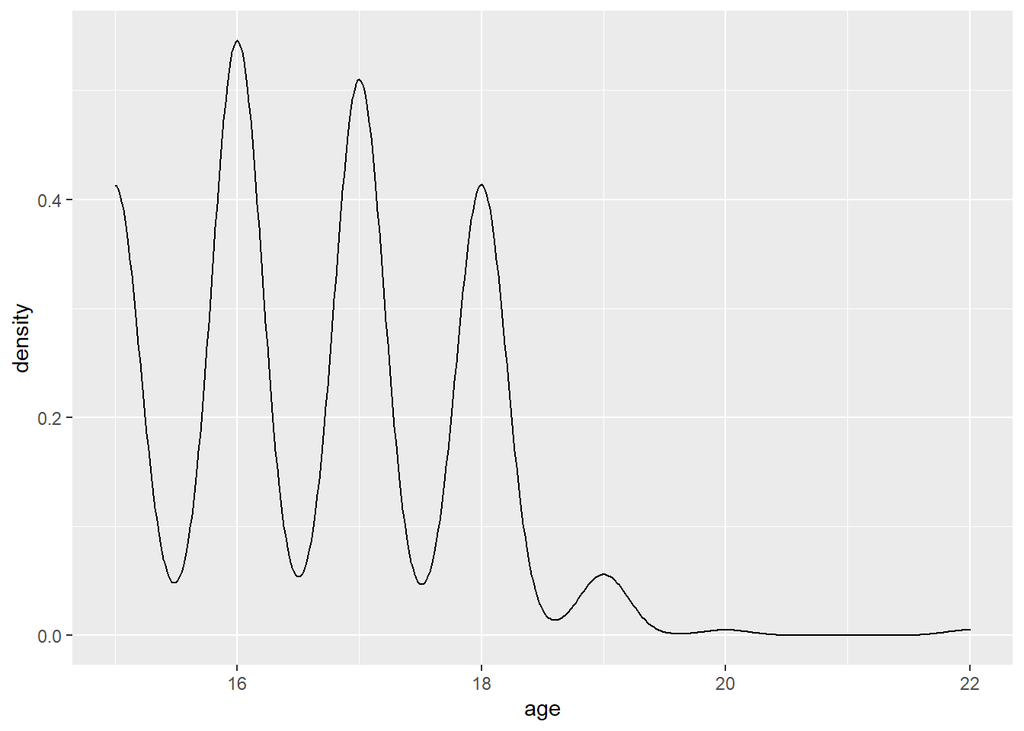

```r
ggplot(schools, aes(x=age)) + geom_density()
```

No normal distribution so age varies.

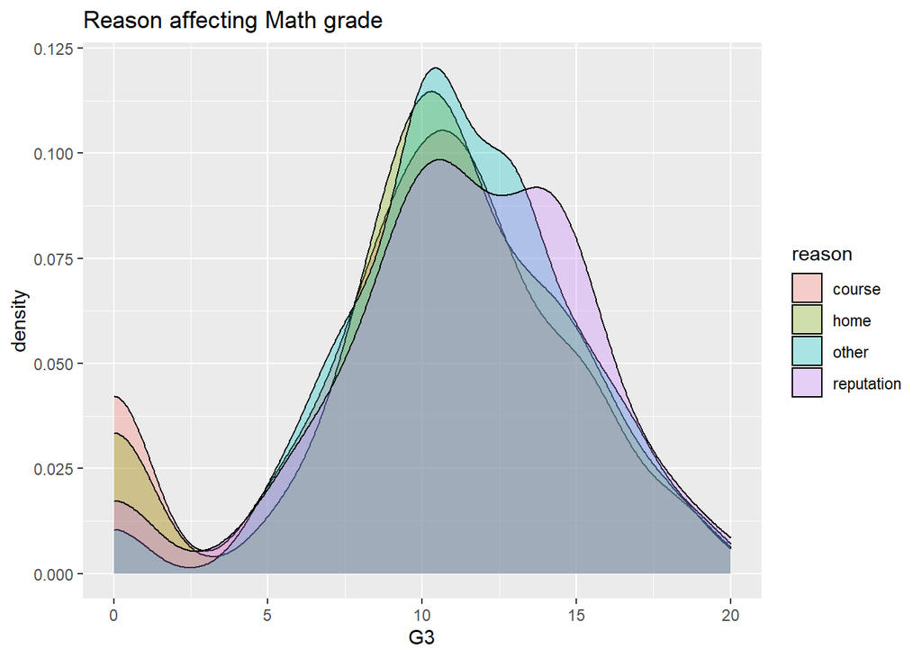

```r
# Reason affecting grades
ggplot(school1, aes(x=G3, fill = reason)) + geom_density(alpha = .3) + ggtitle("Reason affecting Math grade")
```

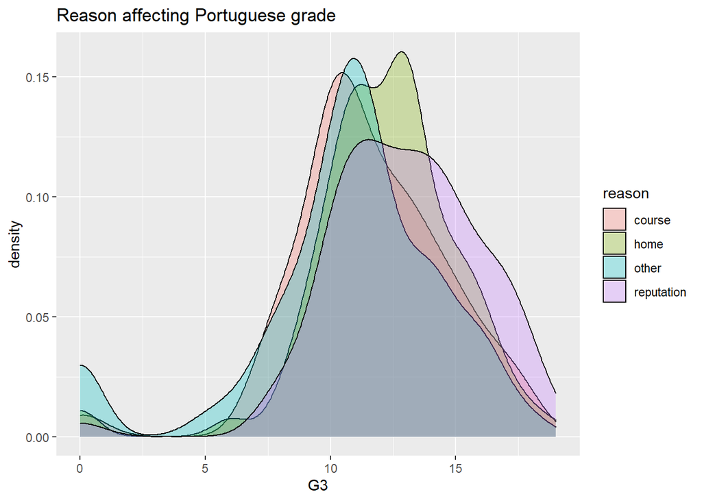

```r
ggplot(school2, aes(x=G3, fill = reason)) + geom_density(alpha = .3) + ggtitle("Reason affecting Portuguese grade")
```

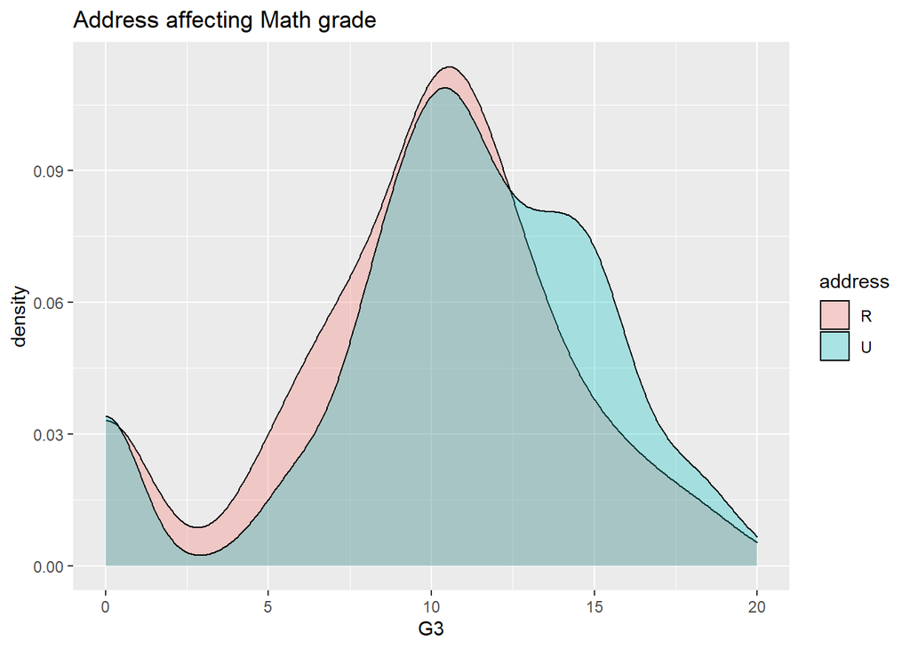

```r
# Address affecting grades
ggplot(school1, aes(x=G3, fill = address)) + geom_density(alpha = .3) + ggtitle("Address affecting Math grade")
```

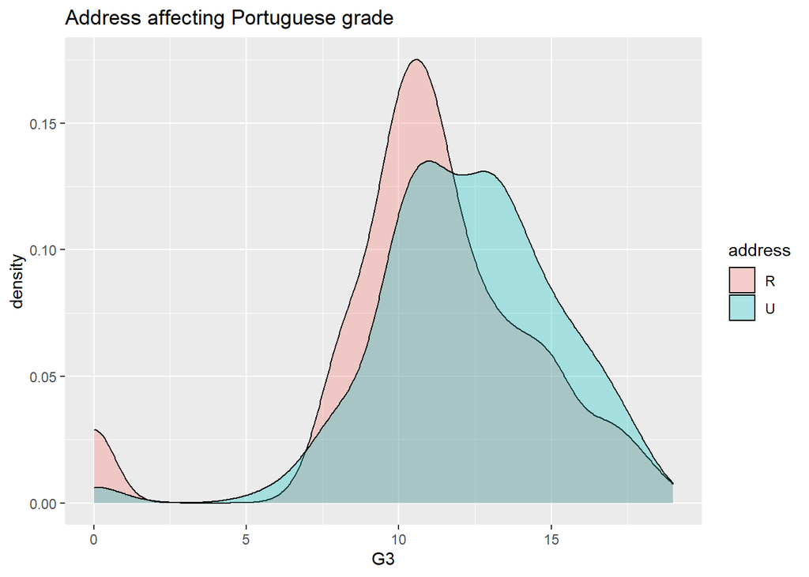

```r
ggplot(school2, aes(x=G3, fill = address)) + geom_density(alpha = .3) + ggtitle("Address affecting Portuguese grade")
```

```r
## Students in Urban region have higher mean final grade than rural region.
```

We can infer that the final grade can be influenced by whether a student lives in a rural or urban region.  
Students in the urban region are more likely to score better for the final grade

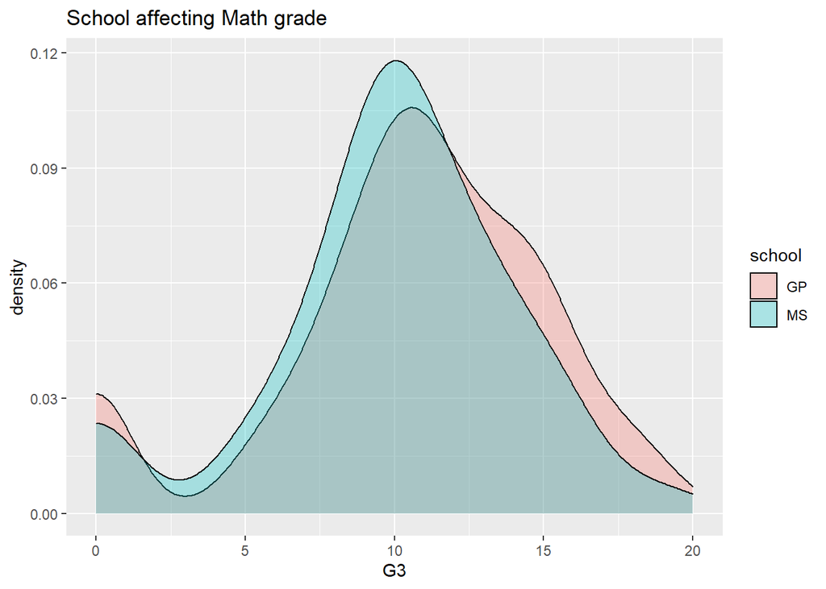

```r
# School affecting grades
ggplot(school1, aes(x= G3, fill = school)) + geom_density(alpha = .3) + ggtitle("School affecting Math grade")
```

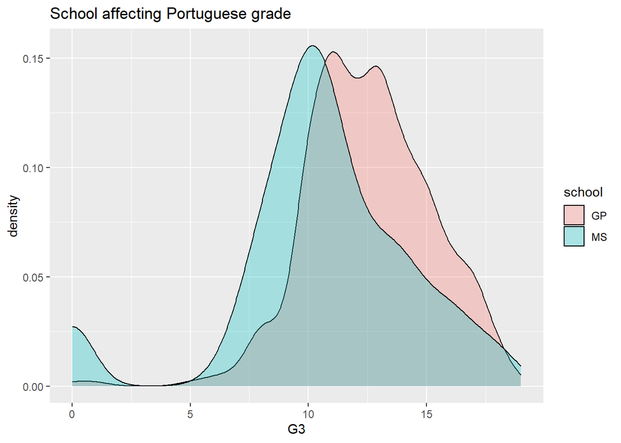

```r
ggplot(school2, aes(x= G3, fill = school)) + geom_density(alpha = .3) + ggtitle("School affecting Portuguese grade")
```

The type of school also influences the final grade, in which students enrolled in GP are more likely to score better in the Portuguese course than in Math.

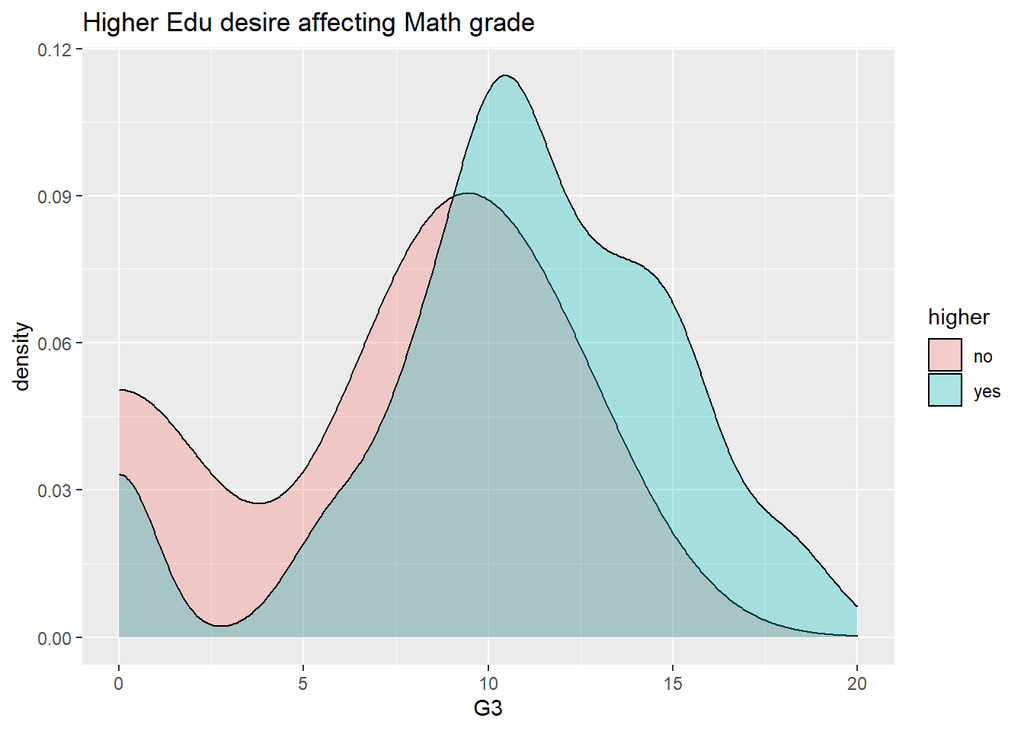

```r
# Desire for higher education affecting grades
ggplot(school1, aes(x= G3, fill = higher)) + geom_density(alpha = .3) + ggtitle("Higher Edu desire affecting Math grade")
```

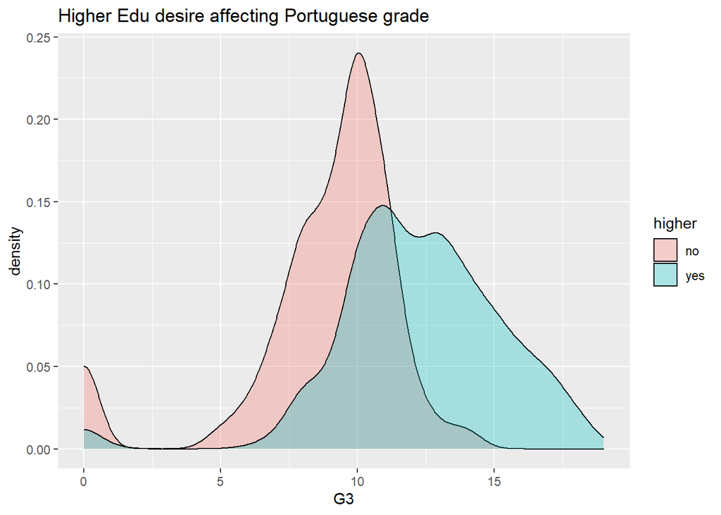

```r
ggplot(school2, aes(x= G3, fill = higher)) + geom_density(alpha = .3) + ggtitle("Higher Edu desire affecting Portuguese grade")
```

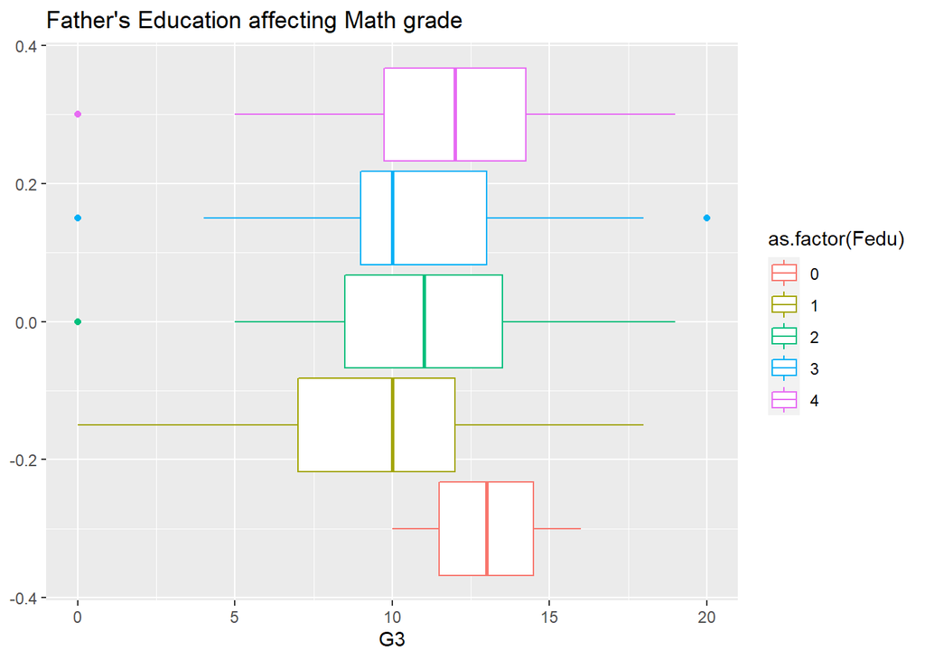

```r
# Father's Education affecting grades
ggplot(school1, aes(x= G3)) + geom_boxplot(aes(color=as.factor(Fedu))) + ggtitle("Father's Education affecting Math grade")
```

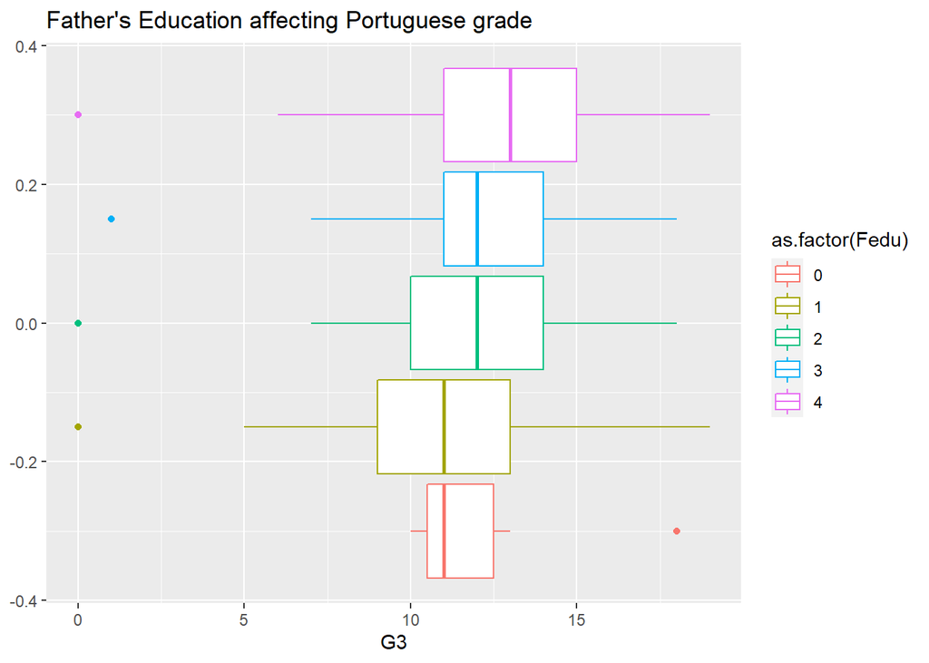

```r
ggplot(school2, aes(x= G3)) + geom_boxplot(aes(color=as.factor(Fedu))) + ggtitle("Father's Education affecting Portuguese grade")
```

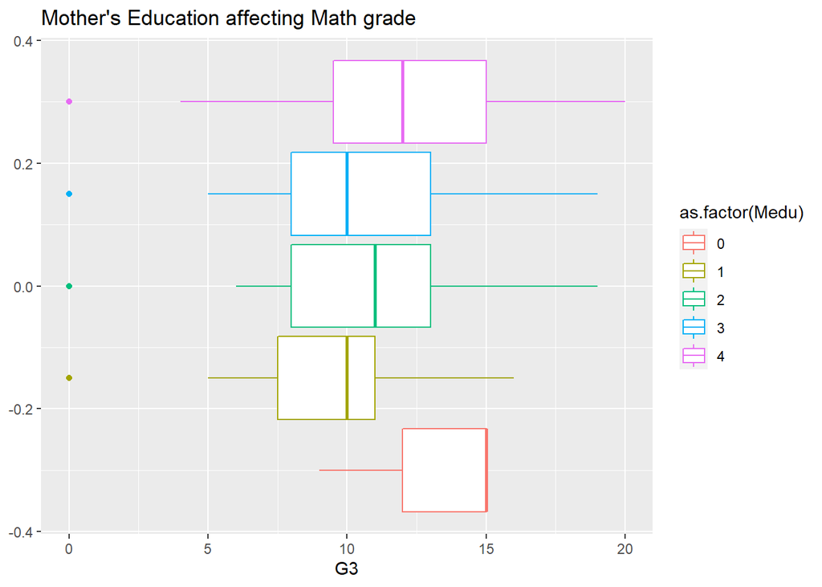

```r
# Mother's Education affecting grades
ggplot(school1, aes(x= G3)) + geom_boxplot(aes(color=as.factor(Medu))) + ggtitle("Mother's Education affecting Math grade")
```

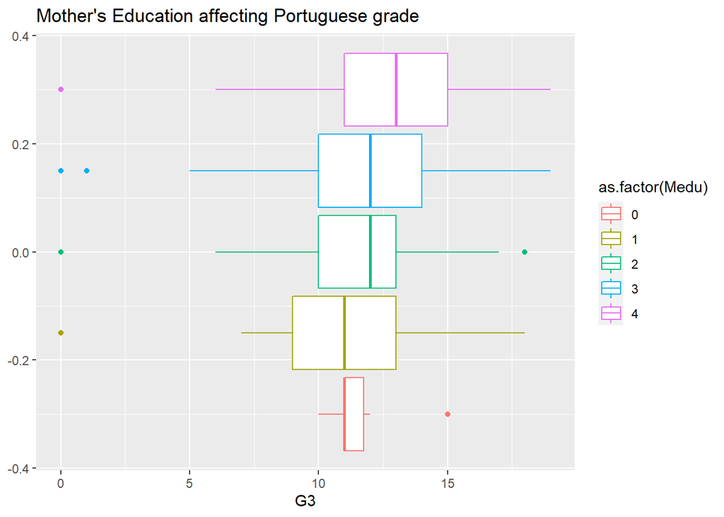

```r
ggplot(school2, aes(x= G3)) + geom_boxplot(aes(color=as.factor(Medu))) + ggtitle("Mother's Education affecting Portuguese grade")
```

The mother’s education can also slightly affect grades as seen above. Other variables such as the reason for choosing the school and desire for higher education are also slightly influential.

We will test out in the following models if these variables are indeed significant.